# Practical Machine Problem Project2

Loading the Testing File

```r
###loading the original Testing file
moveTest <- read.csv("pml-testing.csv")
summary(moveTest)
```

```
##        X            user_name raw_timestamp_part_1 raw_timestamp_part_2
##  Min.   : 1.00   adelmo  :1   Min.   :1.322e+09    Min.   : 36553
##  1st Qu.: 5.75   carlitos:3   1st Qu.:1.323e+09    1st Qu.:268655
##  Median :10.50   charles :1   Median :1.323e+09    Median :530706
##  Mean   :10.50   eurico  :4   Mean   :1.323e+09    Mean   :512167
##  3rd Qu.:15.25   jeremy  :8   3rd Qu.:1.323e+09    3rd Qu.:787738
##  Max.   :20.00   pedro   :3   Max.   :1.323e+09    Max.   :920315
##
##           cvtd_timestamp new_window   num_window      roll_belt
##  30/11/2011 17:11:4      no:20      Min.   : 48.0   Min.   : -5.9200
##  05/12/2011 11:24:3                 1st Qu.:250.0   1st Qu.:  0.9075
##  30/11/2011 17:12:3                 Median :384.5   Median :  1.1100
##  05/12/2011 14:23:2                 Mean   :379.6   Mean   : 31.3055
##  28/11/2011 14:14:2                 3rd Qu.:467.0   3rd Qu.: 32.5050
##  02/12/2011 13:33:1                 Max.   :859.0   Max.   :129.0000
##  (Other)         :5
##    pitch_belt         yaw_belt      total_accel_belt kurtosis_roll_belt
##  Min.   :-41.600   Min.   :-93.70   Min.   : 2.00    Mode:logical
##  1st Qu.:  3.013   1st Qu.:-88.62   1st Qu.: 3.00    NA's:20
##  Median :  4.655   Median :-87.85   Median : 4.00
##  Mean   :  5.824   Mean   :-59.30   Mean   : 7.55
##  3rd Qu.:  6.135   3rd Qu.:-63.50   3rd Qu.: 8.00
##  Max.   : 27.800   Max.   :162.00   Max.   :21.00
##
##  kurtosis_picth_belt kurtosis_yaw_belt skewness_roll_belt
##  Mode:logical        Mode:logical      Mode:logical
##  NA's:20             NA's:20           NA's:20
##
##
##
##
##
##  skewness_roll_belt.1 skewness_yaw_belt max_roll_belt  max_picth_belt
##  Mode:logical         Mode:logical      Mode:logical   Mode:logical
##  NA's:20              NA's:20           NA's:20        NA's:20
##
##
##
##
##
```

[output cut: 289 more lines]

```
##  Min.   :-1.2600   Min.   :-212.0   Min.   :-331.0   Min.   :-282.0
##  1st Qu.:-0.0975   1st Qu.:-114.8   1st Qu.:   8.5   1st Qu.:-199.0
##  Median : 0.2300   Median :  86.0   Median : 138.0   Median :-148.5
##  Mean   : 0.2610   Mean   :  38.8   Mean   : 125.3   Mean   : -93.7
##  3rd Qu.: 0.7625   3rd Qu.: 166.2   3rd Qu.: 268.0   3rd Qu.: -31.0
##  Max.   : 1.8000   Max.   : 232.0   Max.   : 406.0   Max.   : 179.0
##
##  magnet_forearm_x magnet_forearm_y magnet_forearm_z   problem_id
##  Min.   :-714.0   Min.   :-787.0   Min.   :-32.0    Min.   : 1.00
##  1st Qu.:-427.2   1st Qu.:-328.8   1st Qu.:275.2    1st Qu.: 5.75
##  Median :-189.5   Median : 487.0   Median :491.5    Median :10.50
##  Mean   :-159.2   Mean   : 191.8   Mean   :460.2    Mean   :10.50
##  3rd Qu.:  41.5   3rd Qu.: 720.8   3rd Qu.:661.5    3rd Qu.:15.25
##  Max.   : 532.0   Max.   : 800.0   Max.   :884.0    Max.   :20.00
##
```

Reducing the Covariates of the Testing set by applying the same process applied to the Training set:

```r
###reducing the predictors
nzv<-nearZeroVar(moveTest)
moveFiltered2 <- moveTest[, -nzv]
summary(moveFiltered2)
```

```
##        X            user_name raw_timestamp_part_1 raw_timestamp_part_2
##  Min.   : 1.00   adelmo  :1   Min.   :1.322e+09    Min.   : 36553
##  1st Qu.: 5.75   carlitos:3   1st Qu.:1.323e+09    1st Qu.:268655
##  Median :10.50   charles :1   Median :1.323e+09    Median :530706
##  Mean   :10.50   eurico  :4   Mean   :1.323e+09    Mean   :512167
##  3rd Qu.:15.25   jeremy  :8   3rd Qu.:1.323e+09    3rd Qu.:787738
##  Max.   :20.00   pedro   :3   Max.   :1.323e+09    Max.   :920315
##
##           cvtd_timestamp   num_window      roll_belt
##  30/11/2011 17:11:4      Min.   : 48.0   Min.   : -5.9200
##  05/12/2011 11:24:3      1st Qu.:250.0   1st Qu.:  0.9075
##  30/11/2011 17:12:3      Median :384.5   Median :  1.1100
##  05/12/2011 14:23:2      Mean   :379.6   Mean   : 31.3055
##  28/11/2011 14:14:2      3rd Qu.:467.0   3rd Qu.: 32.5050
##  02/12/2011 13:33:1      Max.   :859.0   Max.   :129.0000
##  (Other)         :5
##    pitch_belt         yaw_belt      total_accel_belt  gyros_belt_x
##  Min.   :-41.600   Min.   :-93.70   Min.   : 2.00    Min.   :-0.500
##  1st Qu.:  3.013   1st Qu.:-88.62   1st Qu.: 3.00    1st Qu.:-0.070
##  Median :  4.655   Median :-87.85   Median : 4.00    Median : 0.020
##  Mean   :  5.824   Mean   :-59.30   Mean   : 7.55    Mean   :-0.045
##  3rd Qu.:  6.135   3rd Qu.:-63.50   3rd Qu.: 8.00    3rd Qu.: 0.070
##  Max.   : 27.800   Max.   :162.00   Max.   :21.00    Max.   : 0.240
##
##   gyros_belt_y     gyros_belt_z      accel_belt_x     accel_belt_y
##  Min.   :-0.050   Min.   :-0.4800   Min.   :-48.00   Min.   :-16.00
##  1st Qu.:-0.005   1st Qu.:-0.1375   1st Qu.:-19.00   1st Qu.:  2.00
##  Median : 0.000   Median :-0.0250   Median :-13.00   Median :  4.50
##  Mean   : 0.010   Mean   :-0.1005   Mean   :-13.50   Mean   : 18.35
##  3rd Qu.: 0.020   3rd Qu.: 0.0000   3rd Qu.: -8.75   3rd Qu.: 25.50
##  Max.   : 0.110   Max.   : 0.0500   Max.   : 46.00   Max.   : 72.00
##
##   accel_belt_z     magnet_belt_x    magnet_belt_y   magnet_belt_z
##  Min.   :-187.00   Min.   :-13.00   Min.   :566.0   Min.   :-426.0
##  1st Qu.: -24.00   1st Qu.:  5.50   1st Qu.:578.5   1st Qu.:-398.5
##  Median :  27.00   Median : 33.50   Median :600.5   Median :-313.5
##  Mean   : -17.60   Mean   : 35.15   Mean   :601.5   Mean   :-346.9
##  3rd Qu.:  38.25   3rd Qu.: 46.25   3rd Qu.:631.2   3rd Qu.:-305.0
##  Max.   :  49.00   Max.   :169.00   Max.   :638.0   Max.   :-291.0
##
```

[output cut: 73 more lines]

```
##  Min.   :-282.0   Min.   :-714.0   Min.   :-787.0   Min.   :-32.0
##  1st Qu.:-199.0   1st Qu.:-427.2   1st Qu.:-328.8   1st Qu.:275.2
##  Median :-148.5   Median :-189.5   Median : 487.0   Median :491.5
##  Mean   : -93.7   Mean   :-159.2   Mean   : 191.8   Mean   :460.2
##  3rd Qu.: -31.0   3rd Qu.:  41.5   3rd Qu.: 720.8   3rd Qu.:661.5
##  Max.   : 179.0   Max.   : 532.0   Max.   : 800.0   Max.   :884.0
##
##    problem_id
##  Min.   : 1.00
##  1st Qu.: 5.75
##  Median :10.50
##  Mean   :10.50
##  3rd Qu.:15.25
##  Max.   :20.00
##
```

```r
###determining the names of the selected covariates from the Training set
names(moveTraining2)
```

```
##  [1] "X"                   "user_name"           "pitch_belt"
##  [4] "total_accel_belt"    "gyros_belt_x"        "gyros_belt_y"
##  [7] "accel_belt_z"        "magnet_belt_y"       "magnet_belt_z"
## [10] "roll_arm"            "pitch_arm"           "yaw_arm"
## [13] "total_accel_arm"     "gyros_arm_y"         "accel_arm_z"
## [16] "magnet_arm_y"        "magnet_arm_z"        "roll_dumbbell"
## [19] "pitch_dumbbell"      "yaw_dumbbell"        "gyros_dumbbell_x"
## [22] "gyros_dumbbell_y"    "magnet_dumbbell_y"   "magnet_dumbbell_z"
## [25] "roll_forearm"        "pitch_forearm"       "yaw_forearm"
## [28] "total_accel_forearm" "gyros_forearm_x"     "gyros_forearm_z"
## [31] "accel_forearm_y"     "accel_forearm_z"     "magnet_forearm_x"
## [34] "magnet_forearm_y"    "magnet_forearm_z"    "classe"
```

```r
moveTesting2 <- moveFiltered2[, c("X", "user_name", "pitch_belt",
                                  "total_accel_belt", "gyros_belt_x",
                                  "gyros_belt_y", "accel_belt_z","magnet_belt_y",
                                  "magnet_belt_z", "roll_arm", "pitch_arm",
                                  "yaw_arm", "total_accel_arm", "gyros_arm_y",
                                  "accel_arm_z", "magnet_arm_y", "magnet_arm_z",
                                  "roll_dumbbell", "pitch_dumbbell",
                                  "yaw_dumbbell", "gyros_dumbbell_x",
                                  "gyros_dumbbell_y", "magnet_dumbbell_y",
                                  "magnet_dumbbell_z",
                                  "roll_forearm", "pitch_forearm", "yaw_forearm",
                                  "total_accel_forearm", "gyros_forearm_x",
                                  "gyros_forearm_z",
                                  "accel_forearm_y", "accel_forearm_z",
                                  "magnet_forearm_x",
                                  "magnet_forearm_y", "magnet_forearm_z",
                                  "problem_id")]
```

Checking if Covariates on Training and Test Set are the same

```r
names(moveTesting2)
```

```
##  [1] "X"                   "user_name"           "pitch_belt"
##  [4] "total_accel_belt"    "gyros_belt_x"        "gyros_belt_y"
##  [7] "accel_belt_z"        "magnet_belt_y"       "magnet_belt_z"
## [10] "roll_arm"            "pitch_arm"           "yaw_arm"
## [13] "total_accel_arm"     "gyros_arm_y"         "accel_arm_z"
## [16] "magnet_arm_y"        "magnet_arm_z"        "roll_dumbbell"
## [19] "pitch_dumbbell"      "yaw_dumbbell"        "gyros_dumbbell_x"
## [22] "gyros_dumbbell_y"    "magnet_dumbbell_y"   "magnet_dumbbell_z"
## [25] "roll_forearm"        "pitch_forearm"       "yaw_forearm"
## [28] "total_accel_forearm" "gyros_forearm_x"     "gyros_forearm_z"
## [31] "accel_forearm_y"     "accel_forearm_z"     "magnet_forearm_x"
## [34] "magnet_forearm_y"    "magnet_forearm_z"    "problem_id"
```

```r
names(training)
```

```
##  [1] "X"                   "user_name"           "pitch_belt"
##  [4] "total_accel_belt"    "gyros_belt_x"        "gyros_belt_y"
##  [7] "accel_belt_z"        "magnet_belt_y"       "magnet_belt_z"
## [10] "roll_arm"            "pitch_arm"           "yaw_arm"
## [13] "total_accel_arm"     "gyros_arm_y"         "accel_arm_z"
## [16] "magnet_arm_y"        "magnet_arm_z"        "roll_dumbbell"
## [19] "pitch_dumbbell"      "yaw_dumbbell"        "gyros_dumbbell_x"
## [22] "gyros_dumbbell_y"    "magnet_dumbbell_y"   "magnet_dumbbell_z"
## [25] "roll_forearm"        "pitch_forearm"       "yaw_forearm"
## [28] "total_accel_forearm" "gyros_forearm_x"     "gyros_forearm_z"
## [31] "accel_forearm_y"     "accel_forearm_z"     "magnet_forearm_x"
## [34] "magnet_forearm_y"    "magnet_forearm_z"    "classe"
```

```r
all.equal(names(moveTesting2[,-36]),names(training[,-36]))
```

```
## [1] TRUE
```

*Final Testing File and Plot with updated Classe*

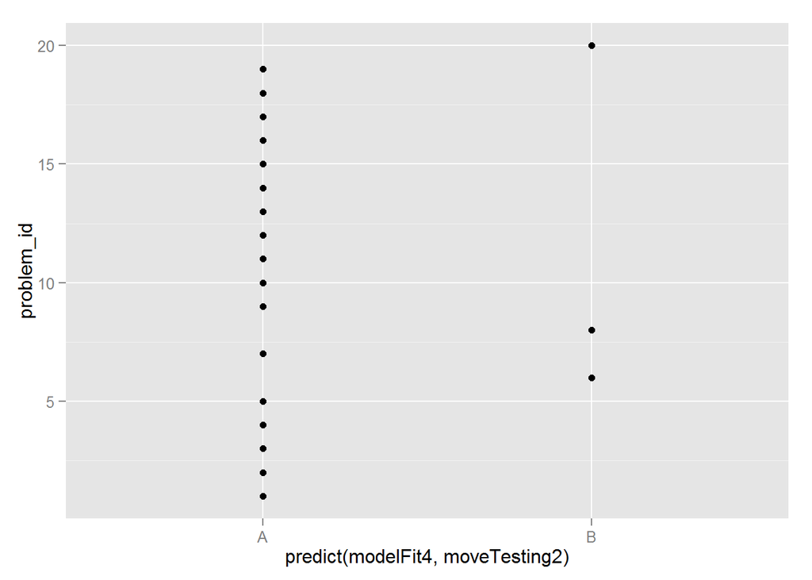

```r
Testing_classe <-  as.data.frame(predict(modelFit4,moveTesting2))
colnames(Testing_classe) <- c('classe')
TestingFinal <- moveTesting2
TestingFinal<- cbind(TestingFinal,Testing_classe)

answers <- predict(modelFit4,moveTesting2)

#pml_write_files = function(x){
#  n = length(x)
#  for(i in 1:n){
#    filename = paste0("problem_id_",i,".txt")
#    write.table(x[i],file=filename,quote=FALSE,row.names=FALSE,col.names=FALSE)
#  }
#}

#pml_write_files(answers)
qplot(predict(modelFit4,moveTesting2), problem_id, data=moveTesting2)
```

*Conclusion* After analyzing the data provided and applying what I have learned so far in this Data Science Specialization Course, I was able to use the Machine Learning principles in predicting the “classe” on how the participants did their exercise as shown on the Testing Set.